# Two Years of Tweets

## What’s in those tweets?

Well, let’s take [`tidytext`](https://github.com/juliasilge/tidytext) out for a spin and see.[^5] We’ll also need to load the `stringr` package because, although it is part of the [`tidyverse`](http://tidyverse.org/) collection of packages, it’s not among the **core** packages that are automatically loaded when you run `library(tidyverse)`.

```r
library(tidytext)
library(stringr)

replace_reg <- "https://t.co/[A-Za-z\\d]+|http://[A-Za-z\\d]+|&amp;|&lt;|&gt;|RT|https"
unnest_reg <- "([^A-Za-z_\\d#@']|'(?![A-Za-z_\\d#@]))"
tidy_tweets <- tweets %>%
  filter(!str_detect(text, "^RT")) %>%
  mutate(text = str_replace_all(text, replace_reg, "")) %>%
  unnest_tokens(word, text, token = "regex", pattern = unnest_reg) %>%
  filter(!word %in% stop_words$word,
         str_detect(word, "[a-z]"))
```

By using `unnest_tokens()`, I broke all of the non-re-tweet tweets down into individual words.

```r
frequency <- tidy_tweets %>%
  group_by(person) %>%
  count(word, sort = TRUE) %>%
  left_join(tidy_tweets %>%
              group_by(person) %>%
              summarise(total = n())) %>%
  mutate(freq = n/total)

library(pander)
pandoc.table(top_n(frequency, 5), style = "rmarkdown")
```

```
##
##
## | person |     word     |  n   | total  |   freq   |
## |:------:|:------------:|:----:|:------:|:--------:|
## |  Mara  |   #rstats    | 2107 | 134088 | 0.01571  |
## |  Mara  |   #dataviz   | 1563 | 134088 | 0.01166  |
## |  Mara  |     data     | 1159 | 134088 | 0.008644 |
## |  Mara  |    icymi     | 590  | 134088 |  0.0044  |
## |  Mara  | @tanyacash21 | 504  | 134088 | 0.003759 |
```

So, it looks like the things I tweet about most are R (`#rstats`), data visualization (`#dataviz`), data (and or stuff pertaining thereto), and heads-up-ing/poking/bugging [tcash](https://twitter.com/tanyacash21). All noble topics in their own right.

```r
tidy_tweets <- tidy_tweets %>%
  filter(timestamp >= as.Date("2016-05-1"),
         timestamp < as.Date("2017-06-1"))
```

```r
words_by_time <- tidy_tweets %>%
  filter(!str_detect(word, "^@")) %>%
  mutate(time_floor = floor_date(timestamp, unit = "1 month")) %>%
  count(time_floor, person, word) %>%
  ungroup() %>%
  group_by(person, time_floor) %>%
  mutate(time_total = sum(n)) %>%
  group_by(word) %>%
  mutate(word_total = sum(n)) %>%
  ungroup() %>%
  rename(count = n) %>%
  filter(word_total > 30)  ## just words w/ 30+ mentions

words_by_time
```

```
## # A tibble: 2,847 x 6
##    time_floor person             word count time_total word_total
##        <dttm>  <chr>            <chr> <int>      <int>      <int>
##  1 2016-05-01   Mara            #d3js     3       3176         48
##  2 2016-05-01   Mara         #datasci     3       3176         51
##  3 2016-05-01   Mara         #dataviz    67       3176        876
##  4 2016-05-01   Mara             #ddj     2       3176         62
##  5 2016-05-01   Mara         #ggplot2     4       3176         41
##  6 2016-05-01   Mara #machinelearning     5       3176         71
##  7 2016-05-01   Mara            #maps     8       3176        100
##  8 2016-05-01   Mara           #maths     4       3176         31
##  9 2016-05-01   Mara             #nba     7       3176        134
## 10 2016-05-01   Mara       #nerdhumor     6       3176         52
## # ... with 2,837 more rows
```

```r
nested_data <- words_by_time %>%
  nest(-word, -person)

nested_data
```

```
## # A tibble: 234 x 3
##    person             word              data
##     <chr>            <chr>            <list>
##  1   Mara            #d3js <tibble [12 x 4]>
##  2   Mara         #datasci <tibble [13 x 4]>
##  3   Mara         #dataviz <tibble [13 x 4]>
##  4   Mara             #ddj <tibble [13 x 4]>
##  5   Mara         #ggplot2 <tibble [13 x 4]>
##  6   Mara #machinelearning <tibble [13 x 4]>
##  7   Mara            #maps <tibble [13 x 4]>
##  8   Mara           #maths <tibble [12 x 4]>
##  9   Mara             #nba <tibble [13 x 4]>
## 10   Mara       #nerdhumor <tibble [13 x 4]>
## # ... with 224 more rows
```

For modeling `purrr`-poses (get it?), next we’re gonna do a little bit of nesting.[^6]

```r
library(purrr)

nested_models <- nested_data %>%
  mutate(models = map(data, ~ glm(cbind(count, time_total) ~ time_floor, .,
                                  family = "binomial")))

nested_models
```

```
## # A tibble: 234 x 4
##    person             word              data    models
##     <chr>            <chr>            <list>    <list>
##  1   Mara            #d3js <tibble [12 x 4]> <S3: glm>
##  2   Mara         #datasci <tibble [13 x 4]> <S3: glm>
##  3   Mara         #dataviz <tibble [13 x 4]> <S3: glm>
##  4   Mara             #ddj <tibble [13 x 4]> <S3: glm>
##  5   Mara         #ggplot2 <tibble [13 x 4]> <S3: glm>
##  6   Mara #machinelearning <tibble [13 x 4]> <S3: glm>
##  7   Mara            #maps <tibble [13 x 4]> <S3: glm>
##  8   Mara           #maths <tibble [12 x 4]> <S3: glm>
##  9   Mara             #nba <tibble [13 x 4]> <S3: glm>
## 10   Mara       #nerdhumor <tibble [13 x 4]> <S3: glm>
## # ... with 224 more rows
```

Using David Robinson’s package, `broom`, we can get the results of our nested models back into a nice and tidy format for further examination, and plotting.

```r
library(broom)

slopes <- nested_models %>%
  unnest(map(models, tidy)) %>%
  filter(term == "time_floor") %>%
  mutate(adjusted.p.value = p.adjust(p.value))
```

```r
top_slopes <- slopes %>%
  filter(adjusted.p.value < 0.1)

top_slopes
```

```
## # A tibble: 9 x 8
##   person        word       term      estimate    std.error statistic
##    <chr>       <chr>      <chr>         <dbl>        <dbl>     <dbl>
## 1   Mara     #rstats time_floor  1.988530e-08 2.850450e-09  6.976196
## 2   Mara #statistics time_floor -6.568951e-08 1.715566e-08 -3.829029
## 3   Mara      archer time_floor  3.798934e-08 1.043280e-08  3.641338
## 4   Mara          bc time_floor  4.699781e-08 1.066157e-08  4.408151
## 5   Mara        code time_floor  3.508227e-08 6.865772e-09  5.109734
## 6   Mara        days time_floor  4.851829e-08 1.340797e-08  3.618614
## 7   Mara      hahaha time_floor  6.632954e-08 1.511174e-08  4.389271
## 8   Mara        step time_floor  4.274309e-08 7.893053e-09  5.415280
## 9   Mara      #polog time_floor -5.841950e-08 1.486084e-08 -3.931102
## # ... with 2 more variables: p.value <dbl>, adjusted.p.value <dbl>
```

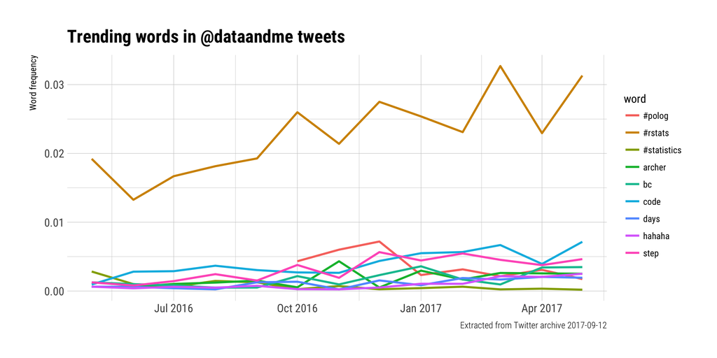

```r
words_by_time %>%
  inner_join(top_slopes, by = c("word", "person")) %>%
  ggplot(aes(time_floor, count/time_total, color = word)) +
  geom_line(size = 1) +
  labs(title = "Trending words in @dataandme tweets",
       x = NULL, y = "Word frequency",
       caption = "Extracted from Twitter archive 2017-09-12") +
  theme_ipsum_rc()
```

## All this made possible by…

```r
library(thankr)
thankees <- shoulders()
library(DT)
datatable(thankees)
```

|  | maintainer | no_packages | packages |
| --- | --- | --- | --- |
| 1 | Hadley Wickham &lt;hadley@rstudio.com&gt; | 15 | assertthat, dplyr, forcats, ggplot2, gtable, haven, httr, lazyeval, modelr, plyr, rvest, scales, stringr, tidyr, tidyverse |
| 2 | R Core Team &lt;R-core@r-project.org&gt; | 11 | base, compiler, datasets, graphics, grDevices, grid, methods, parallel, stats, tools, utils |
| 3 | Kirill Müller &lt;krlmlr+r@mailbox.org&gt; | 5 | bindr, bindrcpp, hms, rprojroot, tibble |
| 4 | Winston Chang &lt;winston@stdout.org&gt; | 4 | extrafont, extrafontdb, R6, Rttf2pt1 |
| 5 | Lionel Henry &lt;lionel@rstudio.com&gt; | 3 | purrr, rlang, tidyselect |
| 6 | Julia Silge &lt;julia.silge@gmail.com&gt; | 2 | janeaustenr, tidytext |
| 7 | Yihui Xie &lt;xie@yihui.name&gt; | 2 | evaluate, knitr |
| 8 | Dirk Eddelbuettel &lt;edd@debian.org&gt; | 2 | digest, Rcpp |
| 9 | JJ Allaire &lt;jj@rstudio.com&gt; | 2 | rmarkdown, rstudioapi |
| 10 | Bob Rudis &lt;bob@rud.is&gt; | 1 | hrbrthemes |

[output cut: 27 more lines]

```r
library(praise)
praise::praise()
```

```
## [1] "You are super-excellent!"
```

[^1]: Julia ([@juliasilge](https://twitter.com/juliasilge)), and Dave ([@drob](https://twitter.com/drob)) are excellent tweeters, well worth following– though, given that you’re reading this, I’m guessing the probability that you already do so is pretty high.
[^2]: See Twitter’s [*Downloading your Twitter archive*](https://support.twitter.com/articles/20170160#) if you want to check out your own 140-character collection.
[^3]: I’m also setting the `separate()` argument `remove = FALSE`. This way we keep the date, and have individual year, month, and day values.
[^4]: Also, as previously mentioned, I want to be super cool like Julia, and she did this for her [Ten Thousand Tweets](https://juliasilge.com/blog/ten-thousand-tweets/) analysis. So, there.
[^5]: Again, I’m still following [Tidy Text Mining with R](http://tidytextmining.com), specifically [*7.2 Word frequencies*](http://tidytextmining.com/twitter.html#word-frequencies-1) here.
[^6]: This is very well explained in the [twitter-case-study section](http://tidytextmining.com/twitter.html) of [Tidy Text Mining with R](http://tidytextmining.com).